# Reproducible Research: Peer Assessment 1

## Introduction

It is now possible to collect a large amount of data about personal movement using activity monitoring devices such as a Fitbit, Nike Fuelband, or Jawbone Up. These type of devices are part of the “quantified self” movement – a group of enthusiasts who take measurements about themselves regularly to improve their health, to find patterns in their behavior, or because they are tech geeks. But these data remain under-utilized both because the raw data are hard to obtain and there is a lack of statistical methods and software for processing and interpreting the data.

This assignment makes use of data from a personal activity monitoring device. This device collects data at 5 minute intervals through out the day. The data consists of two months of data from an anonymous individual collected during the months of October and November, 2012 and include the number of steps taken in 5 minute intervals each day.

###Loading and preprocessing the data

```r
unzip("activity.zip")
data_raw <- read.csv("activity.csv",na.strings = "NA")
data <- data_raw[which(data_raw$steps!= "NA"),]
```

###Histogram of total of steps per day?

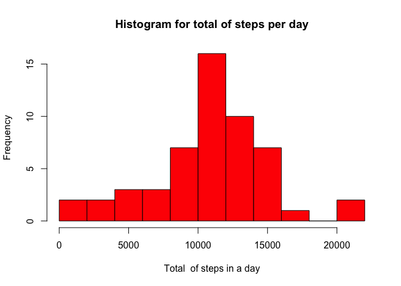

```r
data_sum_steps <- aggregate(steps ~ date, data=data, FUN=sum)
hist(data_sum_steps$steps, breaks=10, col="red", main="Histogram for total of steps per day", xlab="Total  of steps in a day")
```

###What is mean total number of steps taken per day?

```r
mean(data_sum_steps$steps)
```

```
## [1] 10766.19
```

```r
median(data_sum_steps$steps)
```

```
## [1] 10765
```

###What is the average daily activity pattern?

Make a time series plot (i.e. type = “l”) of the 5-minute interval (x-axis) and the average number of steps taken, averaged across all days (y-axis)

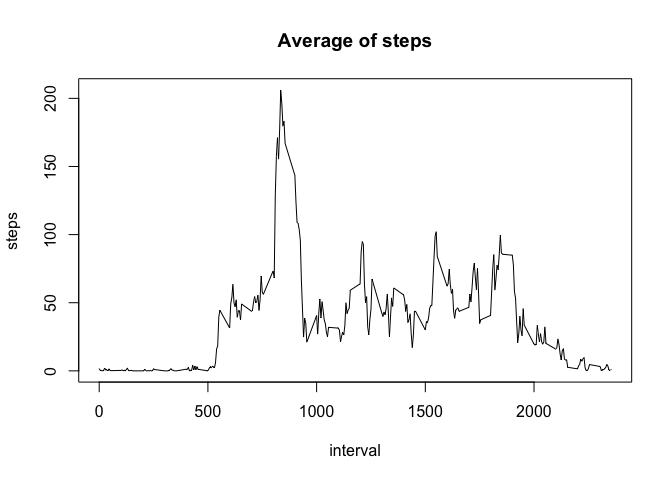

```r
data_interval <- aggregate(steps~ interval,data=data,FUN=mean)
plot(data_interval, type = "l", main="Average of steps")
```

Which 5-minute interval, on average across all the days in the dataset, contains the maximum number of steps?

```r
max_step_by_interval <- data_interval[which.max(data_interval$steps),]
max_step_by_interval
```

```
##     interval    steps
## 104      835 206.1698
```

### Imputing missing values

####Calculate and report the total number of missing values in the dataset (i.e. the total number of rows with NAs)

```r
sum(is.na(data_raw$steps))
```

```
## [1] 2304
```

####Devise a strategy for filling in all of the missing values in the dataset. The strategy does not need to be sophisticated. For example, you could use the mean/median for that day, or the mean for that 5-minute interval, etc.

####I will use the means for the 5-minute intervals as fillers for missing values.

```r
data_fill_missing <- data_raw
for (i in 1:nrow(data_fill_missing) ){
  if ( is.na(data_fill_missing[i,1])){
    tmp <- data_interval[data_interval$interval==data_fill_missing[i,3],2]
    data_fill_missing[i,1] <- tmp
  }
}
```

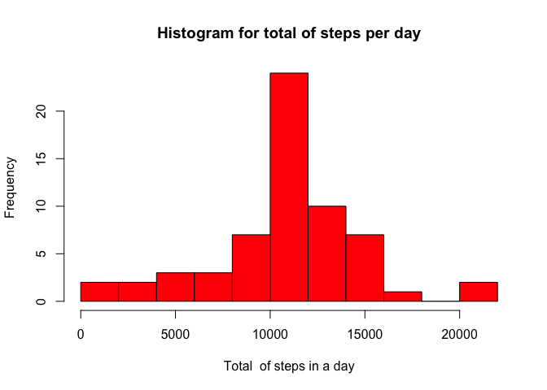

```r
data_new <- aggregate(steps ~ date, data=data_fill_missing, FUN=sum)
hist(data_new$steps, breaks=10, col="red", main="Histogram for total of steps per day", xlab="Total  of steps in a day")
```

```r
mean(data_new$steps)
```

```
## [1] 10766.19
```

```r
median(data_new$steps)
```

```
## [1] 10766.19
```

###Are there differences in activity patterns between weekdays and weekends?

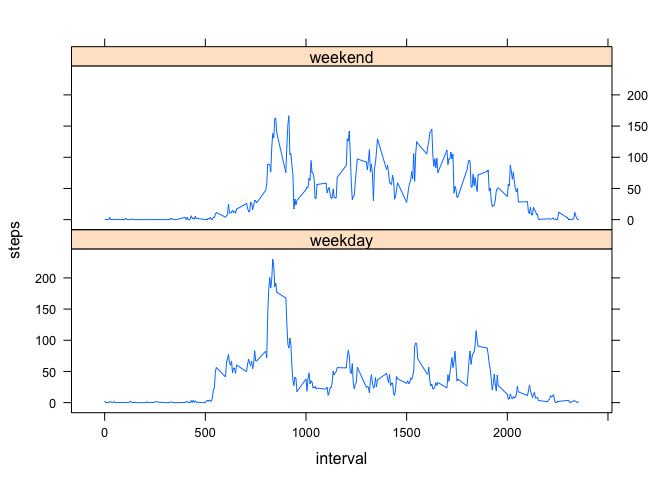

```r
data_fill_missing$date <- as.Date(data_fill_missing$date, "%Y-%m-%d")
data_fill_missing$day <- weekdays(data_fill_missing$date)
data_fill_missing$weekday <- c("weekday")
for(i in 1:nrow(data_fill_missing)){
  if( data_fill_missing[i,4] == "Saturday" || data_fill_missing[i,4] ==  "Sunday"){
    data_fill_missing[i,5] <- c("weekend")
  }
}
data_week <- aggregate(steps ~ interval + weekday, data=data_fill_missing, FUN=mean)
names(data_week) <- c("interval", "day_type", "steps")
library(lattice)
xyplot(steps ~ interval | day_type, data_week, type = "l", layout = c(1, 2))
```